# EDS 223: assignment 1

{Andrew Bartnik}

2022-09-28

## introduction

The following exercises are modified from [Chapter 9 of Geocomputation with R by Rovin Lovelace](https://geocompr.robinlovelace.net/adv-map.html). Each question lists the total number of points. The breakdown of points can be found at the end of each instruction in parentheses. A general grading rubric can be found on the [course website](https://ryoliver.github.io/EDS_223_spatial_analysis/assignments.html).

**Please update “author” to list your first and last names and any collaborators (e.g. Ruth Oliver, Friend1, Friend2)**

**Due by midnight Saturday 2022-10-08**

## prerequisites

```r
library(sf)
library(raster)
library(dplyr)
library(spData)
library(spDataLarge)
library(tmap)
library(grid)
library(leaflet)
```

These exercises rely on a new data object based on the **world** and **worldbank_df** datasets from the **spData* package.

```r
africa = world |>
  filter(continent == "Africa", !is.na(iso_a2)) |>
  left_join(worldbank_df, by = "iso_a2") |>
  dplyr::select(name, subregion, gdpPercap, HDI, pop_growth) |>
  st_transform("+proj=aea +lat_1=20 +lat_2=-23 +lat_0=0 +lon_0=25")
```

We will also use the **zion** and **nlcd** datasets from the **spDataLarge** package.

```r
zion = st_read((system.file("vector/zion.gpkg", package = "spDataLarge")))
data(nlcd, package = "spDataLarge")
force(nlcd)
```

```
## class      : RasterLayer
## dimensions : 1359, 1073, 1458207  (nrow, ncol, ncell)
## resolution : 31.5303, 31.52466  (x, y)
## extent     : 301903.3, 335735.4, 4111244, 4154086  (xmin, xmax, ymin, ymax)
## crs        : +proj=utm +zone=12 +ellps=GRS80 +towgs84=0,0,0,0,0,0,0 +units=m +no_defs
## source     : memory
## names      : layer
## values     : 1, 8  (min, max)
## attributes :
##        ID  colors   levels
##  from:  1 #476ba0    Water
##   to :  8 #bad8ea Wetlands
```

## question 1

##### 10 points

Create a map showing the geographic distribution of the Human Development Index (HDI) across Africa.  
- use both base graphics (hint: use **plot()**) and **tmap**) (4)  
- name two advantages of each based on the experience (3) - name three other mapping packages and an advantage of each (3)

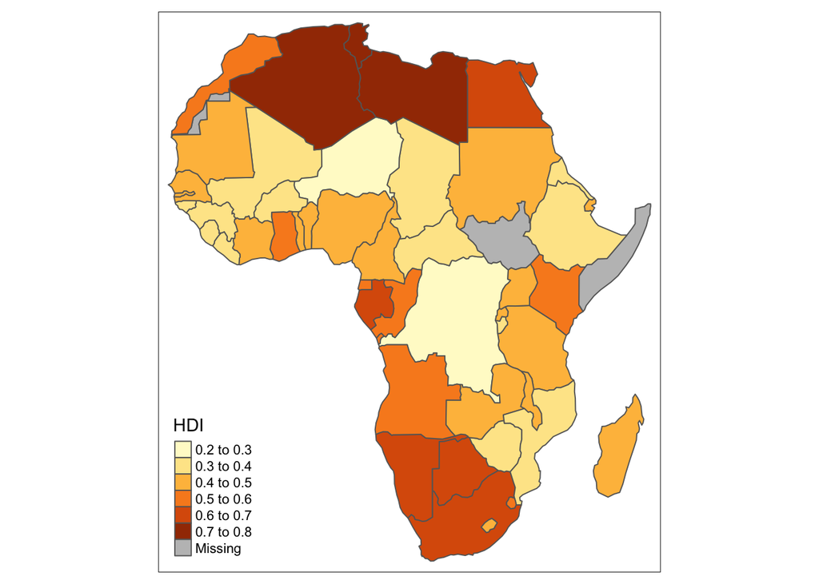

```r
#plotting with tmap
hdi_tmap <- tm_shape(africa) +
  tm_fill(col = 'HDI') +
  tm_borders()

hdi_tmap
```

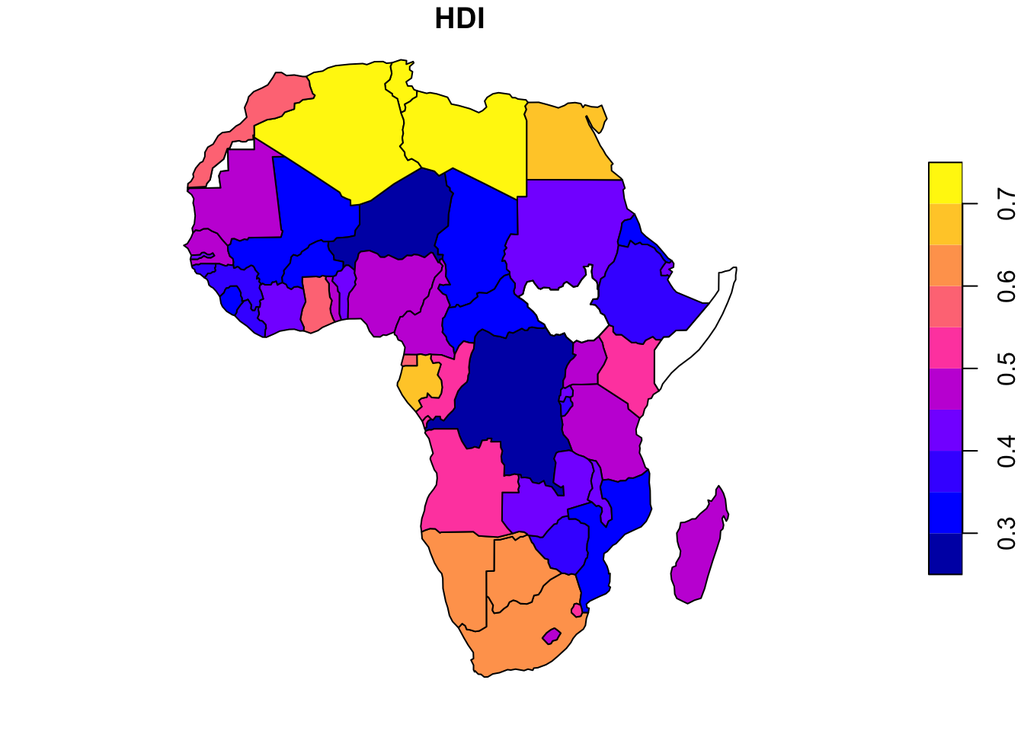

```r
#plotting with base r

hdi_base <- africa |>
  select(HDI, geom)

plot(hdi_base)
```

b)

1. The base R package was fast and simple, and could be especially useful in making quick maps just to visualize during the development phase of a project.
2. Tmap’s base of grammar graphics make it extremely flexible and intuitive, especially for those already familiar with ggplots syntax.It also accepts a wide range of spatial classes, and supports interactive mapping.
1. Globe - plot 2D and 3D views of a sphere, defaults to Earth with its major coastline, additional lines and points
2. mapview - quickly and concisely create interactive maps - provides GIS functionality (mouse position information, attribute queries, scale bar) as its default
3. mapdeck - creates flexible and extensible interactive mapping, specifically useful for visualizing large datasets (can view millions of points) - also uses an interesting ’2.5’D perspective

## question 2

##### 20 points

Extend the **tmap** created for question 1 so the legend has three bins: “high” (HDI above 0.7), “medium” (HDI between 0.55 and 0.7), and “low” (HDI below 0.55). (5)  
- change the legend title (5)  
- change the class labels (5)  
- change the color palette (5)

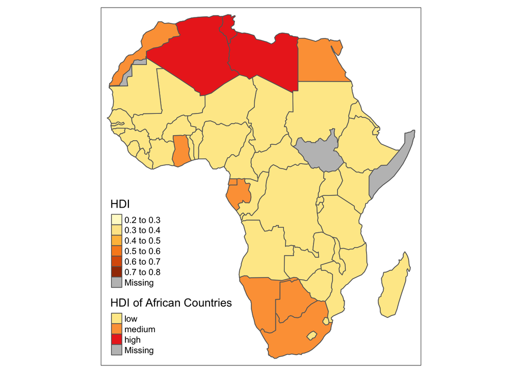

```r
breaks <- c(0, 0.55, 0.7, 0.8) # specifying the breaks for our HDI boundaries
labels = c('low', 'medium', 'high') #Labeling the breaks which we'll use to change the class labels
legend_title = 'HDI of African Countries'


hdi_extended <- hdi_tmap +
  tm_shape(africa) + tm_polygons(col = 'HDI',
                       breaks = breaks,
                       labels = labels,
                       title = legend_title,
                       palette = 'YlOrRd')
hdi_extended
```

## question 3

##### 20 points

Represent Africa’s subregions on the map. (5)  
- change the color palette (5)  
- change the legend title (5)  
- combine this map with the map from question 2 into a single plot (5)

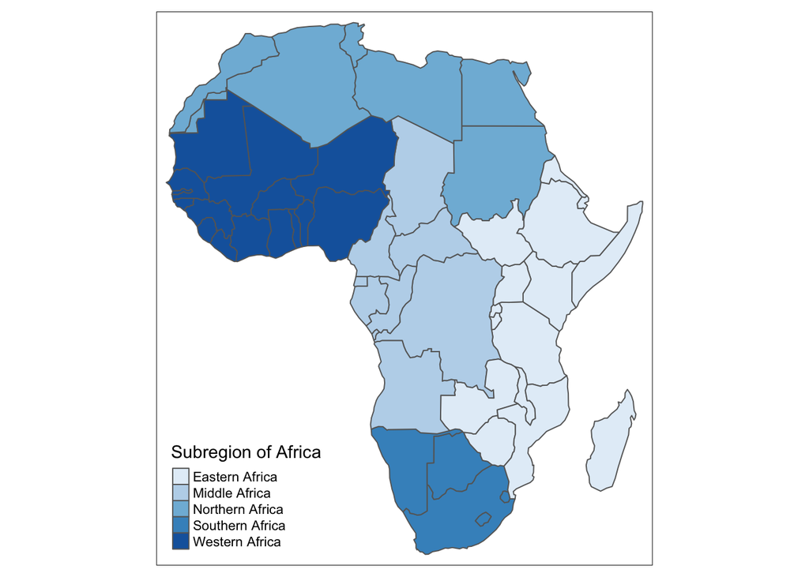

```r
subregions <- tm_shape(africa) +
  tm_polygons(col = 'subregion',
              palette = 'Blues', #changing palette
              title = 'Subregion of Africa') #changing title
subregions
```

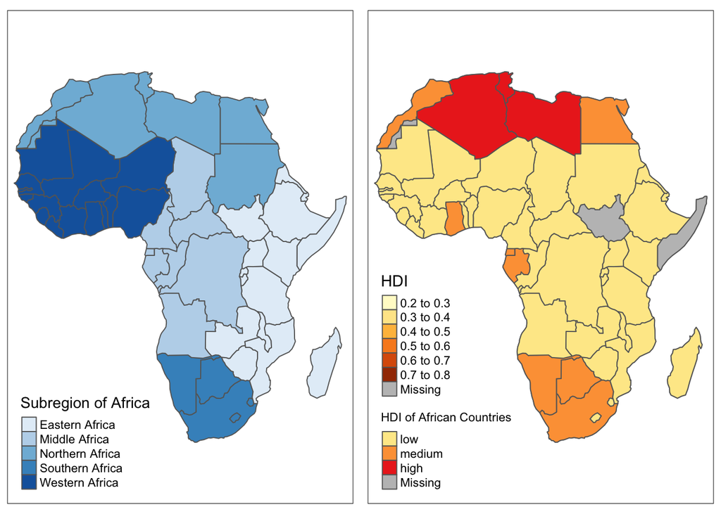

```r
single_plot <- tmap_arrange(subregions, hdi_extended)
single_plot
```

## question 4

##### 30 points

Create a land cover map of Zion National Park (5)  
- change the default colors to match your perception of land cover categories (5)  
- move the map legend outside of the map to improve readability (5)  
- add a scale bar and north arrow and change the position of both to improve the maps aesthetics (5)  
- add the park boundaries on top of the land cover map (5)  
- add an inset of Zion’s location in the context of the state of Utah (5)  
- hint: an object representing Utah can be subset from the **us_states** dataset)

```r
layers_pal <- c('blue','#704007','#666666','forestgreen','darkkhaki','darkgreen','darkred','cyan')


zion_lc <- tm_shape(nlcd) + tm_raster(palette = layers_pal) + #add our raster layer first, using our palette for colors
  tm_shape(zion) + tm_borders(col = 'black') #add our border next, here is our base map


zion_map <- zion_lc + tm_layout(legend.outside = TRUE) + # Moving legend outside of the map
  tm_compass(type = '8star', position = c('left', 'bottom')) + #adding a compass, repositioning
  tm_scale_bar(position = c('left', 'bottom')) #adding a scale bar, repositioning

#Inset map (grid was loaded at start of project)


#this block makes the 'box' of zion that we want to outline - links zion to its region in Utah
utah <- us_states |>
  filter(NAME == 'Utah')
utah_region <- st_bbox(zion,
                     crs = st_crs(nlcd)) |>
  st_as_sfc()

#making the map we want to use as the inset
utah_inset <- tm_shape(utah) +
  tm_polygons() +
  tm_borders() +
  tm_shape(utah_region) +
  tm_borders(col = 'red')

#Printing the two
zion_map
```

```
## stars object downsampled to 888 by 1125 cells. See tm_shape manual (argument raster.downsample)
```

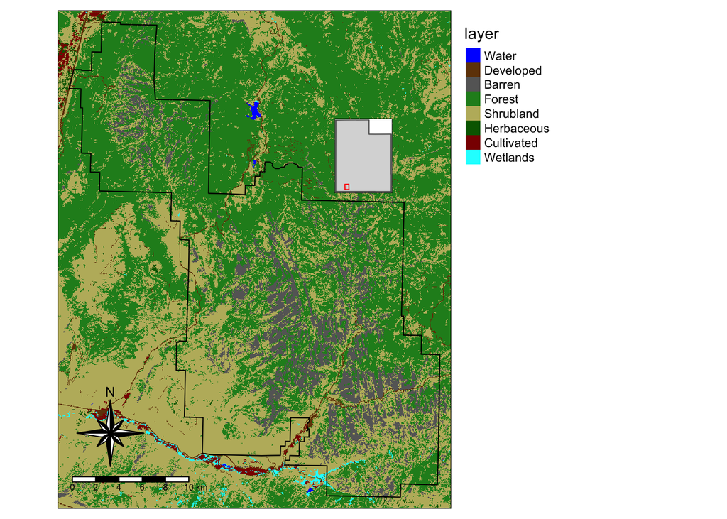

```r
print(utah_inset, vp = viewport(0.5, 0.7, width = 0.3, height = 0.15))
```

## question 5

##### 20 points

Create an interactive map of the world (10)  
- include a legend (5)  
- change the color palette (5)  
- bonus: use **leaflet** insted of **tmap** (2)

```r
#With leaflet

pal <- colorNumeric('Spectral', domain = world$area_km2) #Specify palette first

lf_int <- leaflet(data = world) |>
  addTiles() |>
  addPolygons(col = ~pal(area_km2)) |>
  addLegend(pal = pal, values = ~area_km2) #sequentially add layers

lf_int #Display the plot
```

[interactive chart not shown]

```r
#with tmap

tm_int <- tm_shape(world) + tm_polygons(col = 'continent',
                                        title = 'Continent',
                                        palette = 'Accent') #Making plot
tmap_mode('view') #This command turns our plot interactive - how can we keep data from other columns on plot when we hover over a country?
```

```
## tmap mode set to interactive viewing
```

```r
tm_int #Displaying the plot
```

[interactive chart not shown]

```r
tmap_mode('plot') #switching back to static view for next question
```

```
## tmap mode set to plotting
```

## bonus question

##### 5 points

Create THE WORST map! AKA a map that breaks all of the rules of legibility/clarity, yet somehow still passes for a map. We’ll vote on the best worst map (worst worst map?) in class.

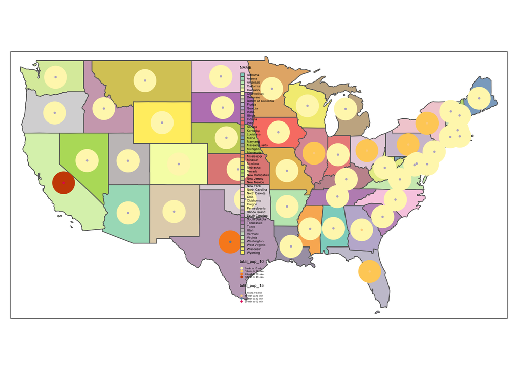

```r
us_bad <- tm_shape(us_states) +
  tm_polygons(col = 'NAME') + #color by every state for legibility and clarity
  tm_layout(legend.position = c('center',  # Make the legend horrendously centered
                                'center')) +
  tmap_options(max.categories = 49) + #Make sure we can fit our whole legend in
  tm_dots(col = 'total_pop_10', #lets display the population of every state in 2010 as a large dot
          size = 4) +
  tm_shape(us_states) +
  tm_dots(col = 'total_pop_15', #and now for the population in 2015 as a small dot
          palette = 'Accent')

us_bad #viola
```